# Task 2: Exploratory Data Analysis

Amber Wang

3/20/2018

## Instructions

The first step in building a predictive model for text is understanding the distribution and relationship between the words, tokens, and phrases in the text. The goal of this task is to understand the basic relationships you observe in the data and prepare to build your first linguistic models.

The goal of this project is just to display that you’ve gotten used to working with the data and that you are on track to create your prediction algorithm. Please submit a report on R Pubs that explains your exploratory analysis and your goals for the eventual app and algorithm. This document should be concise and explain only the major features of the data you have identified and briefly summarize your plans for creating the prediction algorithm and Shiny app in a way that would be understandable to a non-data scientist manager.

You should make use of tables and plots to illustrate important summaries of the data set. The motivation for this project is to: 1. Demonstrate that you’ve downloaded the data and have successfully loaded it in. 2. Create a basic report of summary statistics about the data sets. 3. Report any interesting findings that you amassed so far. 4. Get feedback on your plans for creating a prediction algorithm and Shiny app.

## Tasks to accomplish

1. **Exploratory analysis** - perform a thorough exploratory analysis of the data, understanding the distribution of words and relationship between the words in the corpora.
2. **Understand frequencies of words and word pairs** - build figures and tables to understand variation in the frequencies of words and word pairs in the data.

## Basic setup

### Load libraries

```r
library(quanteda)
library(readtext)
library(stringi)
library(ggplot2)
library(cowplot)
library(reshape2)
```

### Read in data

1. Load data

```r
if(!file.exists('./final/en_US/en_US.blogs.txt')){
  download.file('https://d396qusza40orc.cloudfront.net/dsscapstone/dataset/Coursera-SwiftKey.zip',
                destfile = paste0(getwd(), 'Coursera-SwiftKey.zip'),
                method = 'curl', quiet = T)
  unzip('./Coursera-SwiftKey.zip')
}

rawBlogs <- readtext(paste0(getwd(), '/final/en_US/en_US.blogs.txt'))
rawNews <- readtext(paste0(getwd(), '/final/en_US/en_US.news.txt'))
rawTwts <- readtext(paste0(getwd(), '/final/en_US/en_US.twitter.txt'))
```

2. Calculate number of lines

```r
lines <- data.frame('source' = c('blog', 'news', 'twitter'),
                     'lines' = c(stri_count_fixed(rawBlogs, '\n'),
                                 stri_count_fixed(rawNews, '\n'),
                                 stri_count_fixed(rawTwts, '\n')))
lines
```

```
##    source   lines
## 1    blog  899287
## 2    news 1010241
## 3 twitter 2360147
```

### Create corpus

1. Make individual corpus file

```r
corpBlogs <- corpus(rawBlogs)
docvars(corpBlogs, 'Source') <- 'blogs'

corpNews <- corpus(rawNews)
docvars(corpNews, 'Source') <- 'news'

corpTwts <- corpus(rawTwts)
docvars(corpTwts, 'Source') <- 'twitter'
```

2. Combine into one corpus

```r
corpAll <- corpBlogs + corpNews + corpTwts
```

3. Remove unecesary files to free up memory

```r
rm(rawBlogs, rawNews, rawTwts)
rm(corpBlogs, corpNews, corpTwts)
```

## Data analysis

### Basic summary

1. Get the summary data for the corpus

```r
sum <- summary(corpAll)
sum
```

```
## Corpus consisting of 3 documents:
##
##    Text  Types   Tokens Sentences            doc_id  Source
##   text1 482434 42840147   2077533   en_US.blogs.txt   blogs
##  text11 431664 39918314   1868674    en_US.news.txt    news
##  text12 566950 36719645   2598128 en_US.twitter.txt twitter
##
## Source: Combination of corpuses corpBlogs + corpNews and corpTwts
## Created: Wed Mar 21 23:21:34 2018
## Notes:
```

2. Plot the words and sentences for each data source

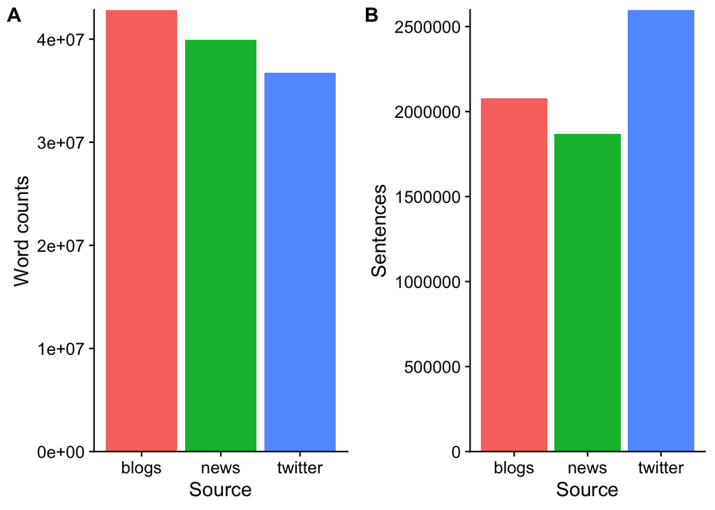

```r
word <- ggplot(data = sum, aes(x = Source, y = Tokens, fill = Source)) +
  geom_col() +
  guides(fill = FALSE) +
  scale_y_continuous(expand = c(0, 0)) +
  ylab('Word counts')

sentence <- ggplot(data = sum, aes(x = Source, y = Sentences, fill = Source)) +
  geom_col() +
  scale_y_continuous(expand = c(0, 0)) +
  guides(fill = FALSE)

plot_grid(word, sentence, labels = 'AUTO')
```

### Preprocessing

1. Write a function to tokenize the corpus and filter profanity

```r
tokenization <- function(input, what = 'word', ngrams = 1L) {

  ## This function calls the tokens function from quanteda
  ## takes an input (character, corpus, or token object)
  ## and returns the tokenized object

  # step1: tokenize based on input values
  results <- tokens(x = input, what = what, ngrams = ngrams,
                    remove_numbers = T, remove_punct = T,
                    remove_symbols = T, remove_separators = T,
                    remove_twitter = T, remove_hyphens = T,
                    remove_url = T)

  # step2: get a list of profanity
  if (!file.exists('badWords.txt')) {
  download.file('https://raw.githubusercontent.com/shutterstock/List-of-Dirty-Naughty-Obscene-and-Otherwise-Bad-Words/master/en',
                dest = paste0(getwd(), 'badWords.txt'),
                method = 'curl', quiet = T)
  }
  prof <- readLines('badWords.txt', skipNul = T)

  # step3: remove profanity
  results <- tokens_remove(results, pattern = prof)
}
```

2. Tokenize words

```r
tokWord <- tokenization(corpAll, what = 'word')
#tokWord <- tokens_tolower(tokWord)
sumWord <- summary(tokWord)
sumWord
```

```
##        Length   Class  Mode
## text1  37102051 -none- character
## text11 33853786 -none- character
## text12 29538860 -none- character
```

3. Tokenize sentences

```r
tokSen <- tokenization(corpAll, what = 'sentence')
sumSen <- summary(tokSen)
sumSen
```

```
##        Length  Class  Mode
## text1   990078 -none- character
## text11  726489 -none- character
## text12 1915673 -none- character
```

4. Plot the tokenized words and sentences for each data source

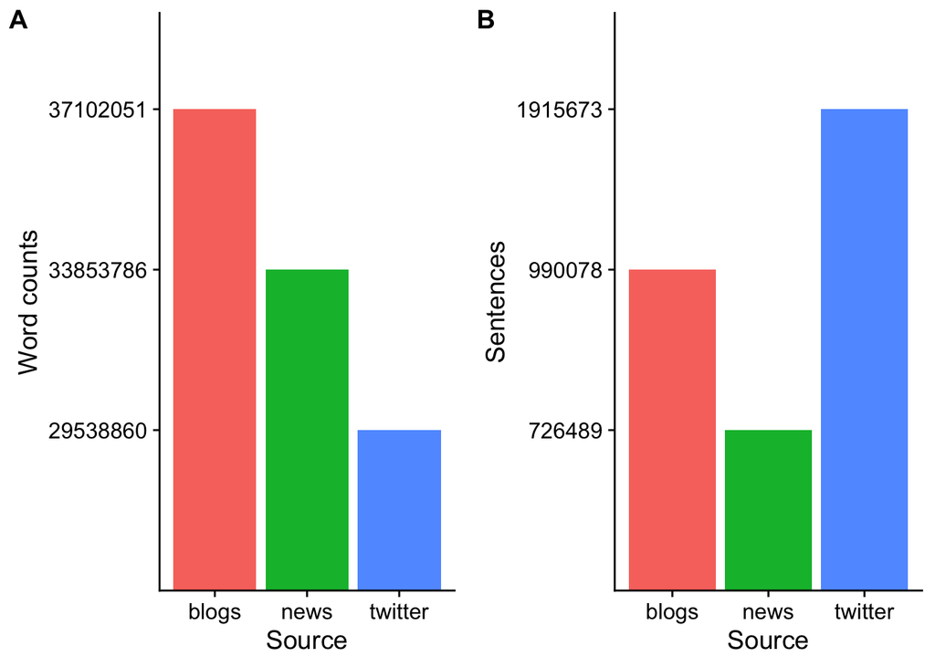

```r
row.names(sumWord) <- c('blogs', 'news', 'twitter')
plotdf <- as.data.frame(sumWord[, 1])
tokWordP <- ggplot(data = plotdf, aes(x = row.names(sumWord), y = sumWord[, 1], fill = row.names(sumWord))) +
  geom_col() +
  guides(fill = FALSE) +
  xlab('Source') +
  ylab('Word counts')

row.names(sumSen) <- c('blogs', 'news', 'twitter')
plotdf <- as.data.frame(sumSen[, 1])
tokSenP <- ggplot(data = sum, aes(x = row.names(sumSen), y = sumSen[, 1], fill = row.names(sumSen))) +
  geom_col() +
  guides(fill = FALSE) +
  xlab('Source') +
  ylab('Sentences')

plot_grid(tokWordP, tokSenP, labels = 'AUTO')
```

### Distributions of word frequencies

#### Single words (1 gram)

- Make a document-feature matrix (dfm) object

```r
dfmWord <- dfm(tokWord, tolower = T) #make a dfm object
```

- Calculate top 20 most frquent words and extract frequencies from individual source

```r
topWordsAll <- topfeatures(dfmWord, n = 20)
  #find top 20 words in all sources
topWordsBlog <- dfmWord[1, names(topWordsAll)]
  #extract frequency of the same 20 words from blogs
topWordsNews <- dfmWord[2, names(topWordsAll)]
  #extract frequency of the same 20 words from news
topWordsTwt <- dfmWord[3, names(topWordsAll)]
  #extract frequency of the same 20 words from twitter
```

- Make a data frame for plotting

```r
gram1dist <- as.data.frame(topWordsAll)
gram1dist <- cbind(gram1dist,
                   t(as.data.frame(topWordsBlog)[, -1]),
                   t(as.data.frame(topWordsNews)[, -1]),
                   t(as.data.frame(topWordsTwt)[, -1]))
colnames(gram1dist) <- c('all', 'blogs', 'news', 'twitter')
gram1dist$words <- row.names(gram1dist)
```

- Plot 1 gram distribution

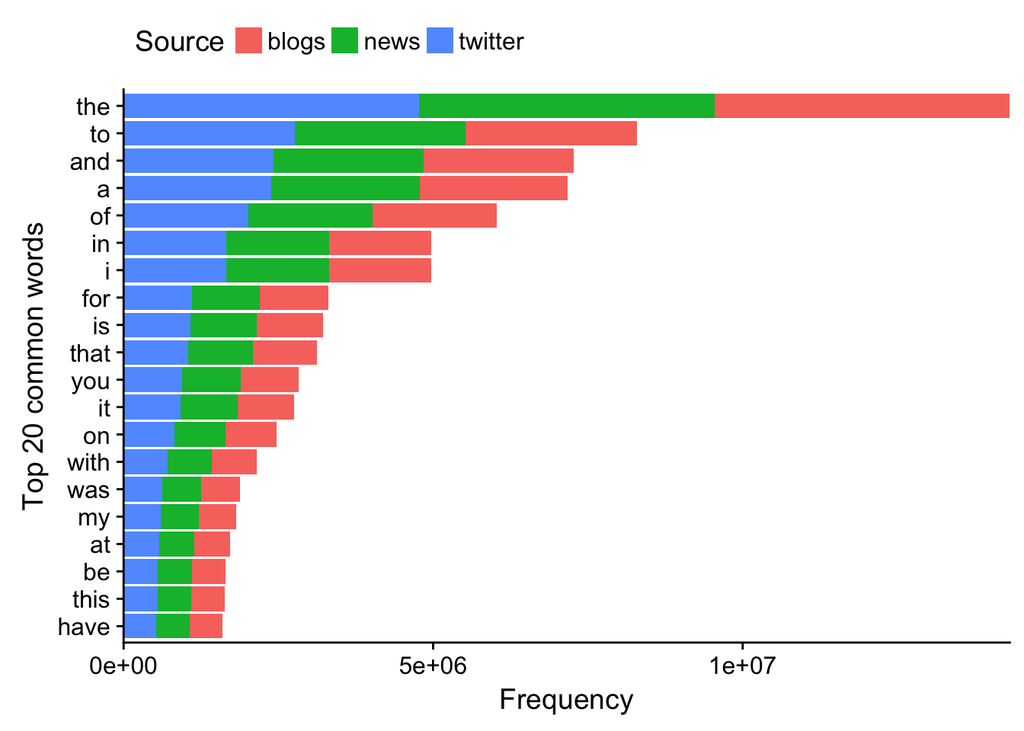

```r
df <- melt(gram1dist, id.vars = c('words', 'all')) #convert to long format
ggplot(data = df, aes(x = reorder(words, all), y = all)) +
  geom_col(aes(fill = variable)) +
  coord_flip() +
  ylab('Frequency') + xlab('Top 20 common words') +
  scale_y_continuous(expand = c(0, 0)) +
  guides(fill = guide_legend(title = 'Source')) +
  theme(legend.position = 'top')
```

- Plot the % of top 10 words across all sources

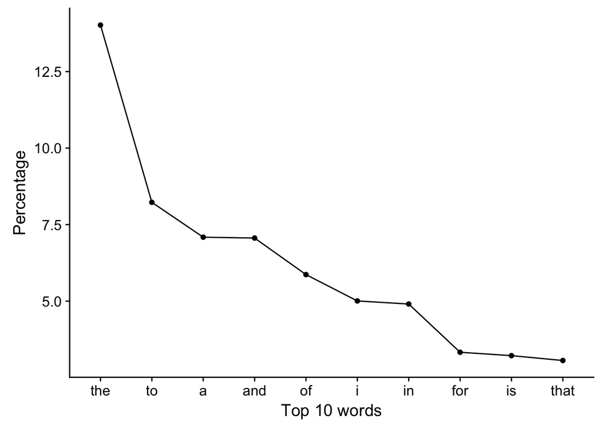

```r
dfmWordPct <- dfm_weight(dfmWord, scheme = 'prop') * 100
dfWordPct <- data.frame(topfeatures(dfmWordPct))
colnames(dfWordPct) <- 'pct'
dfWordPct$words <- row.names(dfWordPct)

ggplot(data = dfWordPct, aes(x = words, y = pct, group = 1)) +
  geom_line() +
  geom_point() +
  scale_x_discrete(limits = dfWordPct$words) +
  xlab('Top 10 words') + ylab('Percentage')
```

#### Remove common words for 1 gram analysis

- The list above shows the common words in English. Remove the stopwords via `remove = stopwords('english')` and allow stem with `stem = T` for more flexible analysis

```r
dfmWordTrim <- dfm(tokWord, tolower = T, stem = T, remove = stopwords('english'))
```

- Identify the top 20 most frquent words

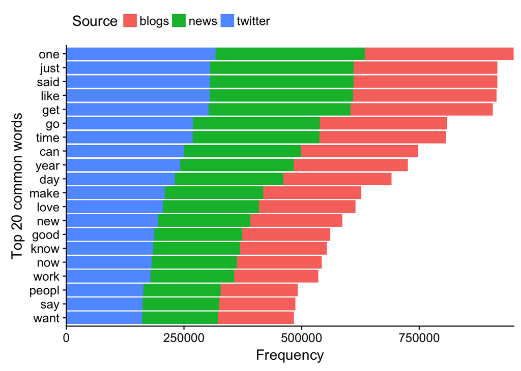

```r
# Extract top 20 words from each source
topWordsTrimAll <- topfeatures(dfmWordTrim, n = 20)
  #find top 20 words in all sources
topWordsTrimBlog <- dfmWordTrim[1, names(topWordsTrimAll)]
  #extract frequency of the same 20 words from blogs
topWordsTrimNews <- dfmWordTrim[2, names(topWordsTrimAll)]
  #extract frequency of the same 20 words from news
topWordsTrimTwt <- dfmWordTrim[3, names(topWordsTrimAll)]
  #extract frequency of the same 20 words from twitter

# Make data frame
gram1distT <- as.data.frame(topWordsTrimAll)
gram1distT <- cbind(gram1distT,
                   t(as.data.frame(topWordsTrimBlog)[, -1]),
                   t(as.data.frame(topWordsTrimNews)[, -1]),
                   t(as.data.frame(topWordsTrimTwt)[, -1]))
colnames(gram1distT) <- c('all', 'blogs', 'news', 'twitter')
gram1distT$words <- row.names(gram1distT)

# Plot 1 gram distribution
df <- melt(gram1distT, id.vars = c('words', 'all')) #convert to long format
ggplot(data = df, aes(x = reorder(words, all), y = all)) +
  geom_col(aes(fill = variable)) +
  coord_flip() +
  ylab('Frequency') + xlab('Top 20 common words') +
  scale_y_continuous(expand = c(0, 0)) +
  guides(fill = guide_legend(title = 'Source')) +
  theme(legend.position = 'top')
```

- Plot the % of top 10 words across all sources

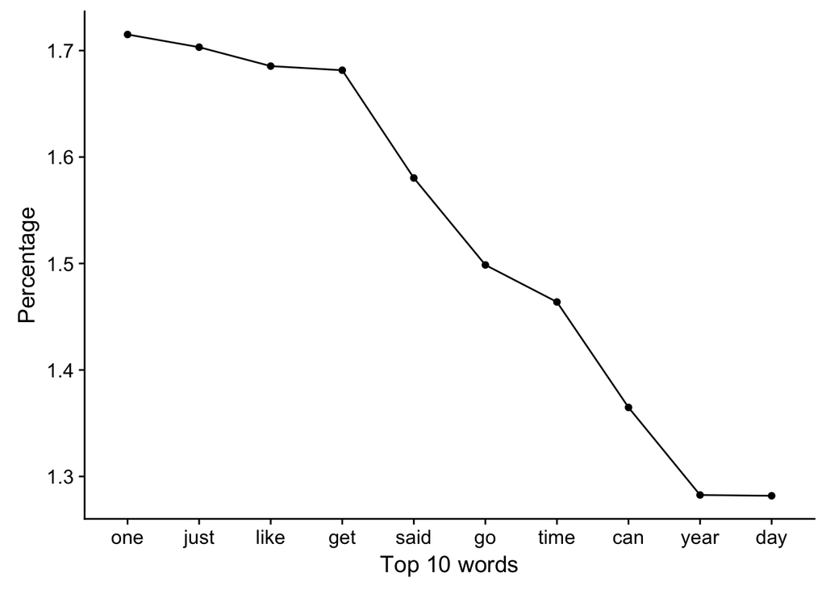

```r
dfmWordTrimPct <- dfm_weight(dfmWordTrim, scheme = 'prop') * 100
dfWordTrimPct <- data.frame(topfeatures(dfmWordTrimPct))
colnames(dfWordTrimPct) <- 'pct'
dfWordTrimPct$words <- row.names(dfWordTrimPct)

ggplot(data = dfWordTrimPct, aes(x = words, y = pct, group = 1)) +
  geom_line() +
  geom_point() +
  scale_x_discrete(limits = dfWordTrimPct$words) +
  xlab('Top 10 words') + ylab('Percentage')
```

#### 2 grams

- Identify 2 grams and make a dfm object

```r
tokWord2g <- tokens_ngrams(tokWord, n = 2L, concatenator = ' ')
dfmWord2g <- dfm(tokWord2g, tolower = T)
```

- Calculate top 20 most frquent 2 grams and extract frequencies from individual source

```r
top2gAll <- topfeatures(dfmWord2g, n = 20)
  #find top 20 2 grams in all sources
top2gBlog <- dfmWord2g[1, names(top2gAll)]
  #extract frequency of the same 20 2 grams from blogs
top2gNews <- dfmWord2g[2, names(top2gAll)]
  #extract frequency of the same 20 2 grams from news
top2gTwt <- dfmWord2g[3, names(top2gAll)]
  #extract frequency of the same 20 2 grams from twitter
```

- Make a data frame for plotting

```r
gram2dist <- as.data.frame(top2gAll)
gram2dist <- cbind(gram2dist,
                   t(as.data.frame(top2gBlog)[, -1]),
                   t(as.data.frame(top2gNews)[, -1]),
                   t(as.data.frame(top2gTwt)[, -1]))
colnames(gram2dist) <- c('all', 'blogs', 'news', 'twitter')
gram2dist$words <- row.names(gram2dist)
```

- Plot 2 gram distribution

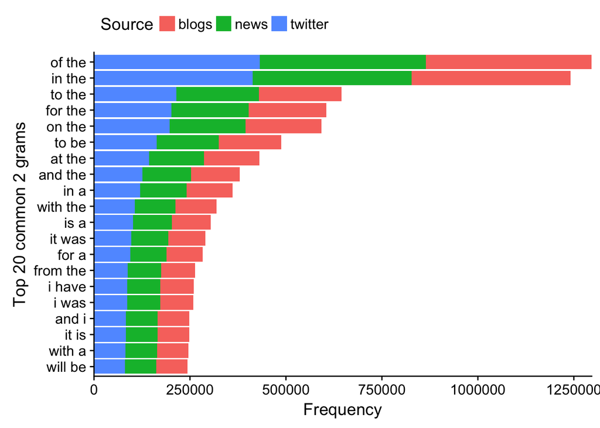

```r
df <- melt(gram2dist, id.vars = c('words', 'all')) #convert to long format
ggplot(data = df, aes(x = reorder(words, all), y = all)) +
  geom_col(aes(fill = variable)) +
  coord_flip() +
  ylab('Frequency') + xlab('Top 20 common 2 grams') +
  scale_y_continuous(expand = c(0, 0)) +
  guides(fill = guide_legend(title = 'Source')) +
  theme(legend.position = 'top')
```

#### 3 grams

- Identify 3 grams and make a dfm object

```r
#Find 3 grams
tokWord3g <- tokens_ngrams(tokWord, n = 3L, concatenator = ' ')
dfmWord3g <- dfm(tokWord3g, tolower = T)
```

- Calculate top 20 most frquent 3 grams and extract frequencies from individual source

```r
#Identify top 20 most common 3 grams
top3gAll <- topfeatures(dfmWord3g, n = 20)[1:20]
top3gBlog <- dfmWord3g[1, names(top3gAll)]
top3gNews <- dfmWord3g[2, names(top3gAll)]
top3gTwt <- dfmWord3g[3, names(top3gAll)]
```

- Make a data frame for plotting

```r
gram3dist <- as.data.frame(top3gAll)
gram3dist <- cbind(gram3dist,
                   t(as.data.frame(top3gBlog)[, -1]),
                   t(as.data.frame(top3gNews)[, -1]),
                   t(as.data.frame(top3gTwt)[, -1]))
colnames(gram3dist) <- c('all', 'blogs', 'news', 'twitter')
gram3dist$words <- row.names(gram3dist)
```

- Plot 3 gram distribution

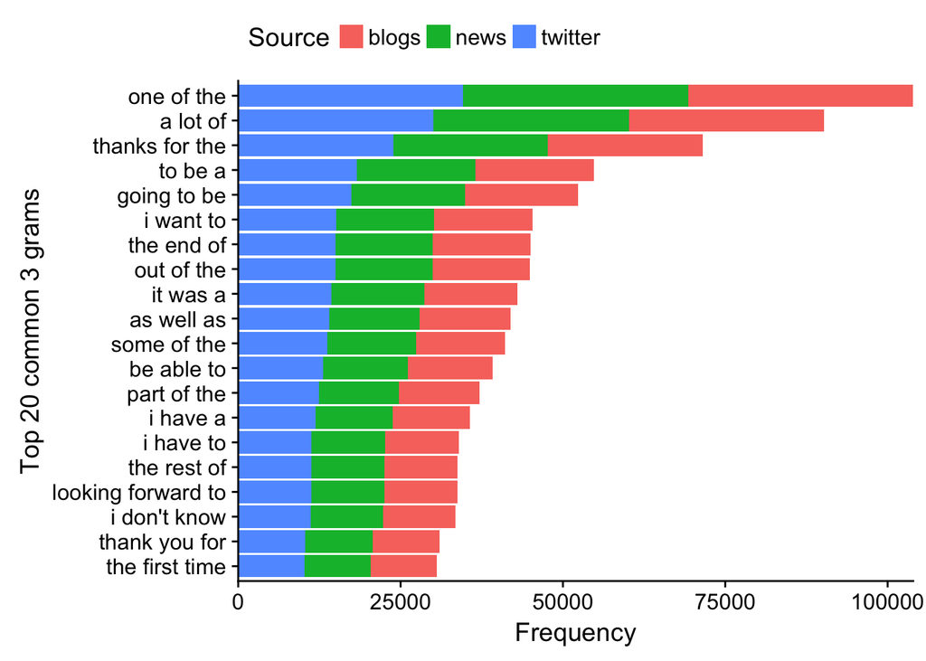

```r
df <- melt(gram3dist, id.vars = c('words', 'all')) #convert to long format
ggplot(data = df, aes(x = reorder(words, all), y = all)) +
  geom_col(aes(fill = variable)) +
  ylab('Frequency') + xlab('Top 20 common 3 grams') +
  coord_flip() +
  scale_y_continuous(expand = c(0, 0)) +
  guides(fill = guide_legend(title = 'Source')) +
  theme(legend.position = 'top')
```

#### Summary of n grams

- Construct a table with the % sparsity of 2 and 3 grams across each source

```r
#sparcity can be accessed by dfmWord2g for all sources and dfmWord2g[1, ] for individual source

nGramSpars <- data.frame('source' = c('all', 'blog', 'news', 'twitter'),
                         'g2spars' = c(58.3, 57, 57, 60.8),
                         'g3spars' = c(62.9, 60.2, 61.9, 66.6))
nGramSpars
```

```
##    source g2spars g3spars
## 1     all    58.3    62.9
## 2    blog    57.0    60.2
## 3    news    57.0    61.9
## 4 twitter    60.8    66.6
```

### Word coverage

- Write a function that calculates the amount of unique words to reach a specified coverage

```r
wordCoverage <- function(inputDfm, coverage){

  ## This function takes in a dfm object and a target coverage
  ## and returns the number of words required to reach that coverage
  ## and the actual coverage reached

  freq <- dfm_weight(inputDfm, scheme = 'prop') * 100
    #calculate percentage frequency for each word
  totalWords <- nfeat(freq)
  freq <- topfeatures(freq, n = totalWords)

  coverageCount <- 0
  wordN <- 0

  for (i in 1:totalWords) {
    if (coverageCount <= coverage) {
      coverageCount <- coverageCount + freq[i]
      wordN <- i
    }
  }
  return(c(wordN, coverageCount))
}
```

- The number of words required to reach 50% or 90% coverage if all words are included

```r
wordCoverage(dfmWord, 50) #50%
```

```
##               the
##  7.00000 52.18241
```

```r
wordCoverage(dfmWord, 90) #90%
```

```
##               the
## 26.00000 90.35665
```

- The number of words required to reach 50% or 90% coverage if stop words are removed

```r
wordCoverage(dfmWordTrim, 50) #50%
```

```
##               one
## 57.00000 50.03899
```

```r
wordCoverage(dfmWordTrim, 90) #90%
```

```
##                 one
## 183.00000  90.14836
```

## Future plans

1. Explore parallelization in R
2. Build basic n-gram model with Markov Chains
3. Inluce 4 grams if my computer can handle it
4. Calculate % of all 2 and 3 grams used. When predciting, return the most frequent regardless of n grams